# SIT 112 - Data Science Concepts - Assignment 1

Lecturer: Sergiy Shelyag | sergiy.shelyag@deakin.edu.au

School of Information Technology,  
Deakin University, VIC 3215, Australia.

### Due: 5pm, Thursday 9th April 2020

### Instructions

This notebook has been prepared for you to complete Assignment 1. Some sections have been pre-filled to help you get started. **The total mark for this programming task is 65**.

1. Before you start, read the entire notebook carefully to understand what you need to do. You should also refer to the main instructions in *Assignment1_instructions.pdf* to know what else you need to complete for this assignment.
2. For each cell marked with *#INSERT YOUR CODE HERE*, you must write your own code in this cell.
3. For each cell marked with *#INSERT YOUR COMMENT HERE*, you must write your own explanatory comment in this cell.
4. At the end, you must run the entire notebook and submit two files:
   1. The source of your solution notebook: [YourID]_assignment1_solution.ipynb
   2. And an exported version of your output: [YourID]_assignment1_output.html

For example, if your student ID is 123456, then you need submit two files:

1. **123456_assignment1_solution.ipynb**
2. and **123456_assignment1_output.html**

As you go through this notebook:

- markdown cells marked with **Note** mean description sections.
- markdown cells marked with **Instructions** mean the instructions given to you to complete the sections.

```python
"""
Import packages needed for processing
"""
import numpy as np   # import the numpy package
import csv           # this package needed for processing csv file
from collections import Counter  # this is for dictionary construction with counting functionality
import matplotlib.pyplot as plt  # this is for plotting and other descriptive statistics
import datetime      # this package is for handling time

"""
If you need add any additional packages, then add them below this line
"""
import operator
import sys

%matplotlib inline
```

**Note**: you must place your data file in the same folder with your python notebook.

```python
# Declare the path to the data file
DATA_FILE = "road_accidents_data_clean.csv" #was no orig
```

**Note**. The following segment of codes is to load the data from the .csv file using csv package. It has been provided for you to get started. Please **do not** change this piece of code as well the variable names as we will need these variables to complete subsequent tasks.

```python
# Load CSV file using DictReader
input_file = csv.DictReader(open(DATA_FILE))
fieldnames = input_file.fieldnames
data_dict = {fn: [] for fn in fieldnames}
print(data_dict.keys())
for line in input_file:
    for k, v in line.items():
        try:
            data_dict[k].append(int(v))
        except ValueError:
            try:
                data_dict[k].append(float(v))
            except ValueError:
                data_dict[k].append(v)

for k, v in data_dict.items():
    data_dict[k] = np.array(v)
```

```
dict_keys(['Index', 'Age', 'Year', 'Crash_Month', 'Crash_Day', 'Crash_Time', 'Road_User', 'Gender', 'Crash_Type', 'Injury_Severity', 'Crash_LGA', 'Crash_Area_Type'])
```

## **Instruction 1**

We first examine the variables and the overall data size. The tasks:

1. Write your code to print the type for the following variables (**4 marks**):
   - input_file
   - data_dict
   - data_dict['Road_User']
   - data_dict['Age']
1. Write your code to print out the number of data records (**1 mark**):

[**Total mark: 5**]

```python
# INSERT YOUR CODE HERE
print('the type of input_file is', type(input_file))
print('the type of data_dict is', type(data_dict))
print('the type of data_dict[\'Road_User\'] is', type(data_dict['Road_User']))
print('the type of data_dict[\'Age\'] is', type(data_dict['Age']))
```

```
the type of input_file is <class 'csv.DictReader'>
the type of data_dict is <class 'dict'>
the type of data_dict['Road_User'] is <class 'numpy.ndarray'>
the type of data_dict['Age'] is <class 'numpy.ndarray'>
```

```python
# INSERT YOUR CODE HERE
print('There are', data_dict['Index'][-1], 'of data records')
```

```
There are 115543 of data records
```

## Instruction 2

The following code segment is designed to calculate some basic statistics from the data.

**Your task:**

1. Write your code to find and print the minimum and the maximum values in the **Age** column. (**1 mark**)
2. Write your code to find and print the minimum and the maximum values in the **Year** column. (**1 mark**)
3. Write your code to find and print the mean and median age, and the standard deviation from the **Age** column. (**2 marks**)
4. Write your code to construct a box plot for the **Age**. (**2 marks**)
5. Briefly describe the meaning of the difference between the mean and median ages. (**4 marks**)

**[Total mark: 10]**

```python
# INSERT YOUR CODE HERE
print('The minimum value in the \'Age\' column is', min(data_dict['Age']))
print('The maximum value in the \'Age\' column is', max(data_dict['Age']))
```

```
The minimum value in the 'Age' column is 16
The maximum value in the 'Age' column is 79
```

```python
# INSERT YOUR CODE HERE
print('The minimum value in the \'Year\' column is', min(data_dict['Year']))
print('The maximum value in the \'Year\' column is', max(data_dict['Year']))
```

```
The minimum value in the 'Year' column is 2000
The maximum value in the 'Year' column is 2019
```

```python
# INSERT YOUR CODE HERE
print('The mean value in the \'Age\' column is', np.mean(data_dict['Age']))
print('The median value in the \'Age\' column is', np.median(data_dict['Age']))
print('The standard deviation value in the \'Age\' column is', np.std(data_dict['Age']))
```

```
The mean value in the 'Age' column is 40.174050769856585
The median value in the 'Age' column is 36.0
The standard deviation value in the 'Age' column is 18.741891462455634
```

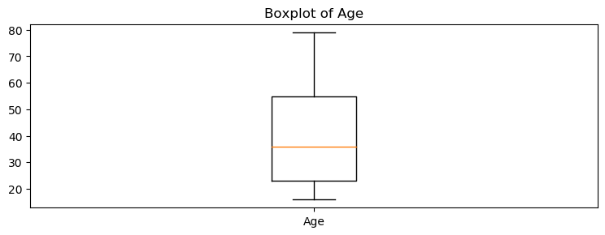

```python
# INSERT YOUR CODE HERE
plt.figure(figsize = (9,3), dpi=100)
plt.boxplot(data_dict['Age'], labels=['Age'])
plt.title('Boxplot of Age')
plt.show()
```

```python
# INSERT YOUR COMMENT HERE
"""
MEAN = Sum of all 'Age' values divided by number of data records
MEDIAN = The middle value for the 'Age' column
"""
```

```
"\nMEAN = Sum of all 'Age' values divided by number of data records\nMEDIAN = The middle value for the 'Age' column\n"
```

## **Instruction 3**

The following code segment is designed to examine data from the **Road_User** column. This column provides information about the types of road users involved in road accidents.

**Your tasks**:

1. Write your code to find and print out the number of **unique** road user types. (**2 marks**)
2. Write your code to find and print out the list of road user types that appear more than **16000** times in the dataset. (**2 marks**)
3. Write your code to find and print out the road user type with highest occurrence of accidents. Both the road user type and the number of accidents for the road user type need to be printed out (**2 marks**)
4. Write your code to construct a dictionary variable: *accidents_by_road_user* whose keys are unique road user types and values are the corresponding counts computed from the dataset. Print the dictionary. (**2 marks**)
5. Plot a bar chart for *accidents_by_road_user* sorted in descending order of values. (**2 marks**)

[**Total mark: 10**]

```python
# INSERT YOUR CODE HERE
print(len(set(data_dict['Road_User'])))
```

```
6
```

```python
# INSERT YOUR CODE HERE
count_road_user = Counter(data_dict['Road_User'])
for i in set(data_dict['Road_User']):
    if (count_road_user[i] > 16000):
        print (i)
```

```
PASSENGER
MOTORCYCLIST
DRIVER
```

```python
# INSERT YOUR CODE HERE
highest_road_user = ""
highest_occured = 0
for i in set(data_dict['Road_User']):
    if (count_road_user[i] > highest_occured):
        highest_road_user = i
        highest_occured = count_road_user[i]

print(highest_road_user, "OCCURED:", highest_occured, "TIMES")
```

```
DRIVER OCCURED: 53000 TIMES
```

```python
# INSERT YOUR CODE HERE
accidents_by_road_user = {}
for i in set(data_dict['Road_User']):
    accidents_by_road_user[i] = count_road_user[i]

print(accidents_by_road_user)
```

```
{'PEDESTRIAN': 12544, 'UNKNOWN': 2704, 'PASSENGER': 22543, 'MOTORCYCLIST': 18474, 'BICYCLIST': 6276, 'DRIVER': 53000}
```

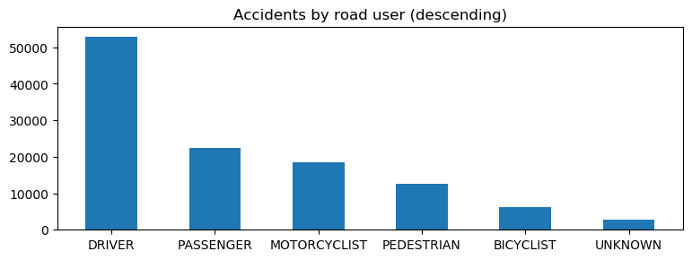

```python
# INSERT YOUR CODE HERE
#Resize
plt.figure(figsize = (9,3), dpi=100)
plt.title('Accidents by road user (descending)')
desc_accidents_by_road_user = dict(sorted(accidents_by_road_user.items(),key=operator.itemgetter(1),reverse=True))
plt.bar(desc_accidents_by_road_user.keys(), desc_accidents_by_road_user.values(), 0.5)
plt.show()
```

## **Instruction 4**

We shall further examine statistics of the road accidents in the dataset. **Your tasks here are:**

1. Write your code to print the number of males and females involved in accidents in the dataset. (**3 marks**)
2. Write your code to create indices of records for males and females in the dataset (**2 marks**)
3. Write your code to plot a histogram of number of accidents by age for females and males separately. Use 10-year bins. Plot both distributions on the same plot. (**2 marks**)
4. Briefly describe the meaning of the obtained results. (**3 marks**)

[**Total mark: 10**]

```python
#INSERT YOUR CODE HERE
count_gender = Counter(data_dict['Gender'])
for i in set(data_dict['Gender']):
    if (i == "FEMALE" or i == "MALE"):
        print(i, "OCCURED:", count_gender[i])
```

```
MALE OCCURED: 66310
FEMALE OCCURED: 49173
```

```python
#INSERT YOUR CODE HERE
for idx, x in enumerate(data_dict['Gender']):
    print(idx, x)
```

[output not shown]

[output cut: 115526 more lines]

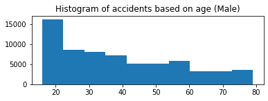

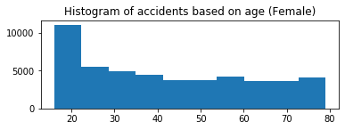

```python
#INSERT YOUR CODE HERE
data_dict_male = []
data_dict_female = []

counter = 0;
for i in data_dict['Gender']:
    if (i == "MALE"):
        data_dict_male.append(data_dict['Age'][counter])
    else:
        data_dict_female.append(data_dict['Age'][counter])
    counter += 1

plt.subplot(2, 1, 1)
plt.title('Histogram of accidents based on age (Male)')
plt.hist(data_dict_male, bins = 10)
plt.show()

plt.subplot(2, 1, 2)
plt.title('Histogram of accidents based on age (Female)')
plt.hist(data_dict_female, bins = 10)
plt.show()
```

```python
#INSERT YOUR COMMENT HERE
# Meaning that:
# 1. Accidents commonly occurred in the age around 20s for both male and female.
# 2. Accident getting decrease after age of 30s for both male and female
```

## **Instruction 5**

**Your tasks**:

1. Define a function called **compute_time_day_year** that takes Year, Crash_Month, Crash_Day and Crash_Time as the inputs and returns day of week (Monday, Tuesday, Wednesday, Thursday, Friday, Saturday, Sunday), time of the day (Morning - 06:00-11:59, Afternoon - 12:00-17:59, Evening - 18:00-23:59, Night - 00:00 - 05:59), and season of the year (Winter for June, July and August; Spring for September, October, November; Summer for December, January, February; Autumn for March, April, May). If either of the input parameters is in incorrect form, the function returns `INVALID` in all outputs. (**4 marks**)
2. Write your code to calculate an array containing the day of week, the time of the day and the season of the year for all accident records. Print the first 10 entries in the array. (**2 marks**)
3. Construct a new array called **valid_DTS_list** to store only valid entries and then print out the number of elements in the array. (**3 marks**)
4. Compute the accident numbers for each of the days of week in the dataset and plot them as a bar chart. Also, print minimum, maximum, mean and median of the computed accident numbers. (**1 mark**)
5. Compute the accident numbers for each of the seasons (Summer, Autumn, Winter, Spring) in the dataset and plot them as a bar chart. (**1 mark**)
6. Compute the accident numbers with Injury_Severity equal to 1 for each of the times of the day (Morning, Afternoon, Evening, Night) in the dataset and plot them as a bar chart. (**1 mark**)
7. Why is the median of the accident numbers integer and the mean is not? Write a brief answer. (**3 marks**)

[**Total mark: 15**]

```python
# INSERT YOUR CODE HERE
def compute_time_day_year(inp_year, inp_month, inp_day, inp_time):
    str_day = ''
    str_time = ''
    str_season = ''
    #     for day
    if (inp_day == 1):
        str_day='Monday'
    elif (inp_day == 2):
        str_day='Tuesday'
    elif (inp_day== 3):
        str_day='Wednesday'
    elif (inp_day== 4):
        str_day='Thursday'
    elif (inp_day == 5):
        str_day='Friday'
    elif (inp_day == 6):
        str_day='Saturday'
    elif (inp_day == 7):
        str_day='Sunday'
    else:
        return 'INVALID'

    #     for time
    #     Converting the time
    if (inp_time != 'UNKNOWN'):
        inp_time = datetime.datetime.strptime(inp_time, '%H:%M:%S').time()
    else:
        return 'INVALID'
    if (inp_time.hour >=6 and inp_time.hour <=11):
        str_time='Morning'
    elif (inp_time.hour >=12 and inp_time.hour <=17):
        str_time='Afternoon'
    elif (inp_time.hour >=18 and inp_time.hour <=23):
        str_time='Evening'
    elif (inp_time.hour >=0 and inp_time.hour <=5):
        str_time='Night'

    #      for season
    if (inp_month >= 6 and inp_month <= 8):
        str_season='Winter'
    elif (inp_month >= 9 and inp_month <= 11):
        str_season='Spring'
    elif (inp_month == 12 or inp_month == 1 or inp_month == 2):
        str_season='Summer'
    elif (inp_month >= 3 and inp_month <= 5):
        str_season='Autumn'
    else:
        return 'INVALID'

    return str_day+' '+str_time+' on '+str_season

compute_time_day_year(data_dict['Year'][0], data_dict['Crash_Month'][0], data_dict['Crash_Day'][0], data_dict['Crash_Time'][0])
```

```
'Monday Night on Summer'
```

```python
# INSERT YOUR CODE HERE
data_datetime_arr = []
for i in range(0, data_dict['Index'][-1]-2):
    data_datetime_arr.append(compute_time_day_year(data_dict['Year'][i], data_dict['Crash_Month'][i], data_dict['Crash_Day'][i], data_dict['Crash_Time'][i]))

for i in range (0,10):
    print(compute_time_day_year(data_dict['Year'][i], data_dict['Crash_Month'][i], data_dict['Crash_Day'][i], data_dict['Crash_Time'][i]))
```

```
Monday Night on Summer
Monday Night on Summer
Monday Night on Summer
Monday Night on Summer
Monday Night on Summer
Monday Night on Summer
Monday Night on Summer
Monday Night on Summer
Monday Night on Summer
Monday Night on Summer
```

```python
# INSERT YOUR CODE HERE
valid_DTS_list = []
for i in data_datetime_arr:
    if (i != 'INVALID'):
        valid_DTS_list.append(i)

print('There are', len(valid_DTS_list), 'crash data that are valid')
print('There are', data_dict['Index'][-1], 'of data records')
```

```
There are 111056 crash data that are valid
There are 115543 of data records
```

```
The minimum value is Friday which is 15450
The maximum value is Wednesday which is 14099
The mean value is 15865.142857142857
The median value is Saturday
```

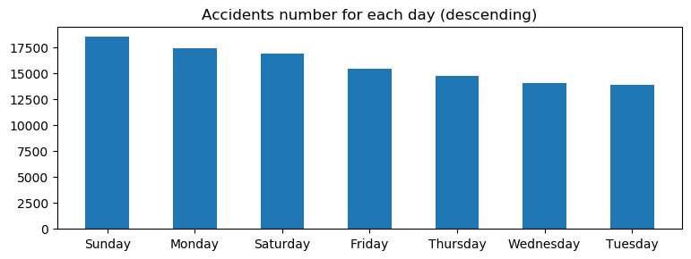

```python
# INSERT YOUR CODE HERE
day_arr = []
for i in valid_DTS_list:
    day_arr.append(i.split()[0])

count_day = Counter(day_arr)

day_dict = {}
for i in set(day_arr):
    day_dict[i] = count_day[i]

print('The minimum value is', min(day_dict), 'which is', day_dict[min(day_dict)])
print('The maximum value is', max(day_dict), 'which is', day_dict[max(day_dict)])
print('The mean value is', len(valid_DTS_list)/7)
print('The median value is', day_arr[int(len(valid_DTS_list)/2)])

plt.figure(figsize = (9,3), dpi=100)
plt.title('Accidents number for each day (descending)')
desc_count_day = dict(sorted(count_day.items(),key=operator.itemgetter(1),reverse=True))
plt.bar(desc_count_day.keys(), desc_count_day.values(), 0.5)
plt.show()
```

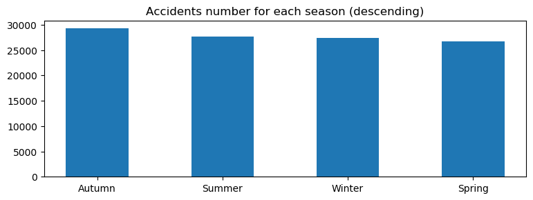

```python
# INSERT YOUR CODE HERE
season_arr = []
for i in valid_DTS_list:
    season_arr.append(i.split()[3])

count_season = Counter(season_arr)

season_dict = {}
for i in set(season_arr):
    season_dict[i] = count_season[i]

plt.figure(figsize = (9,3), dpi=100)
plt.title('Accidents number for each season (descending)')
desc_count_season = dict(sorted(count_season.items(),key=operator.itemgetter(1),reverse=True))
plt.bar(desc_count_season.keys(), desc_count_season.values(), 0.5)
plt.show()
```

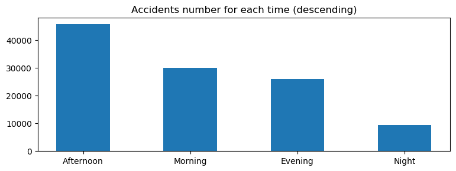

```python
# INSERT YOUR CODE HERE
time_arr = []
for i in valid_DTS_list:
    time_arr.append(i.split()[1])

count_time = Counter(time_arr)

time_dict = {}
for i in set(time_arr):
    time_dict[i] = count_time[i]

plt.figure(figsize = (9,3), dpi=100)
plt.title('Accidents number for each time (descending)')
desc_count_time = dict(sorted(count_time.items(),key=operator.itemgetter(1),reverse=True))
plt.bar(desc_count_time.keys(), desc_count_time.values(), 0.5)
plt.show()
```

```python
#INSERT YOUR COMMENT HERE
# Extrime values won't effect on median, which it will on mean
```